# Day 21 Activity: Where in the World Should You Live?

ECON 122

Your Name Here

```r
library(ggplot2)
library(dplyr)
library(tidyr)
library(readr)
```

## Your Mission

You’re a data consultant for a career services company that helps recent graduates and young professionals choose where to launch their careers. Your clients are overwhelmed by choices: Should I move to Singapore or Stockholm? Is Lisbon better than Lima?

Your job: Use PCA to simplify the decision! You’ll analyze cities across multiple dimensions:

- **Cost of Living**: How expensive is it?
- **Quality of Life**: Healthcare, environment, infrastructure
- **Safety**: Crime rates, political stability
- **Climate**: Temperature, sunshine, weather patterns
- **Culture**: Arts, entertainment, diversity
- **Economy**: Job market, salaries, innovation

**Time limit: 40 minutes**

## Part 1: Explore the Cities (5 minutes)

```r
# Load world cities data
cities <- read_csv("https://raw.githubusercontent.com/mgelman/data/master/livable_cities.csv")

# Take a look
head(cities)
```

```
## # A tibble: 6 × 12
##    Rank City       Country     `Quality of Life Index` `Purchasing Power Index`
##   <dbl> <chr>      <chr>                         <dbl>                    <dbl>
## 1     1 The Hague  Netherlands                    224.                     139.
## 2     2 Luxembourg Luxembourg                     221.                     176.
## 3     3 Eindhoven  Netherlands                    218.                     139.
## 4     4 Rotterdam  Netherlands                    214.                     139.
## 5     5 Zurich     Switzerland                    208.                     181.
## 6     6 Copenhagen Denmark                        202.                     124.
## # ℹ 7 more variables: `Safety Index` <dbl>, `Health Care Index` <dbl>,
## #   `Cost of Living Index` <dbl>, `Property Price to Income Ratio` <dbl>,
## #   `Traffic Commute Time Index` <dbl>, `Pollution Index` <dbl>,
## #   `Climate Index` <dbl>
```

```r
names(cities)
```

```
##  [1] "Rank"                           "City"
##  [3] "Country"                        "Quality of Life Index"
##  [5] "Purchasing Power Index"         "Safety Index"
##  [7] "Health Care Index"              "Cost of Living Index"
##  [9] "Property Price to Income Ratio" "Traffic Commute Time Index"
## [11] "Pollution Index"                "Climate Index"
```

The dataset includes metrics for major world cities. Key variables include:

- `Purchasing Power Index`: Buying power (higher = better salaries vs costs)
- `Safety Index`: How safe the city is (higher = safer)
- `Health Care Index`: Quality of healthcare (higher = better)
- `Cost of Living Index`: Relative cost (higher = more expensive)
- `Property Price to Income Ratio`: Housing affordability (lower = more affordable)
- `Traffic Commute Time Index`: Transportation quality (lower = better)
- `Pollution Index`: Air quality and environment (lower = cleaner)
- `Climate Index`: Weather pleasantness (higher = better)

**Question 1.1:** How many cities are in the dataset? Which cities have the highest cost of living? Which cities are the safest?

```r
# How many cities?
n_cities <- nrow(cities)
n_cities
```

```
## [1] 150
```

```r
# Highest cost of living
expensive_cities <- cities %>%
  arrange(desc(`Cost of Living Index`)) %>%
  select(City, `Cost of Living Index`) %>%
  head(10)
expensive_cities
```

```
## # A tibble: 10 × 2
##    City          `Cost of Living Index`
##    <chr>                          <dbl>
##  1 Geneva                         102.
##  2 Zurich                         100.
##  3 New York                       100
##  4 San Francisco                   90.5
##  5 Boston                          85.8
##  6 Reykjavik                       83.9
##  7 Washington                      82.5
##  8 Seattle                         81.5
##  9 Los Angeles                     80.9
## 10 Chicago                         80.2
```

```r
# Safest cities
safe_cities <- cities %>%
  arrange(desc(`Safety Index`)) %>%
  select(City, `Safety Index`) %>%
  head(10)
safe_cities
```

```
## # A tibble: 10 × 2
##    City      `Safety Index`
##    <chr>              <dbl>
##  1 Abu Dhabi           88.2
##  2 Doha                83.9
##  3 Dubai               83.7
##  4 Taipei              83.7
##  5 Muscat              80.6
##  6 The Hague           79.8
##  7 Munich              79.7
##  8 Ljubljana           78.9
##  9 Zagreb              78.7
## 10 Hong Kong           78.4
```

```r
# Store top 3 for inline text
top_expensive <- expensive_cities %>% slice(1:3) %>% pull(City) %>% paste(collapse = ", ")
top_safe <- safe_cities %>% slice(1:3) %>% pull(City) %>% paste(collapse = ", ")
```

**Your answer:** There are 150 cities in the dataset. The most expensive cities include Geneva, Zurich, New York. The safest cities include Abu Dhabi, Doha, Dubai.

**Question 1.2:** Make a quick scatter plot of Cost of Living vs Pollution. What pattern do you see? (Are clean cities more expensive?)

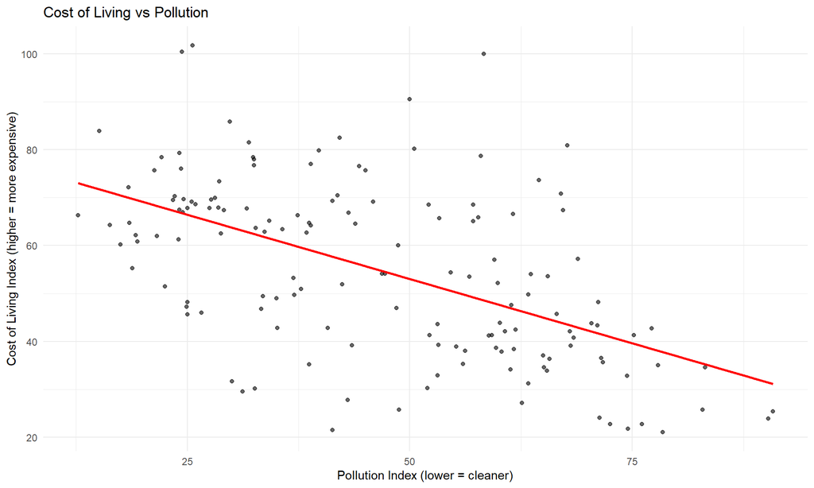

```r
# Create a scatter plot
ggplot(cities, aes(x = `Pollution Index`, y = `Cost of Living Index`)) +
  geom_point(alpha = 0.6) +
  geom_smooth(method = "lm", se = FALSE, color = "red") +
  labs(title = "Cost of Living vs Pollution",
       x = "Pollution Index (lower = cleaner)",
       y = "Cost of Living Index (higher = more expensive)") +
  theme_minimal()
```

**Your observation:** There appears to be a negative relationship between pollution and cost of living. Cities with lower pollution (cleaner air) tend to have higher costs of living. This suggests that environmental quality comes at a premium price in the housing/living market.

## Part 2: The PCA Transformation (8 minutes)

Eight different factors to consider is overwhelming! Let’s use PCA to simplify.

**Question 2.1:** Run PCA on the 8 quality-of-life metrics. Remember to standardize!

```r
# Select only the 8 quality metrics using select()
city_metrics <- cities %>%
  select(`Purchasing Power Index`, `Safety Index`, `Health Care Index`,
         `Cost of Living Index`, `Property Price to Income Ratio`,
         `Traffic Commute Time Index`, `Pollution Index`, `Climate Index`)

# Perform PCA with standardization
pca_cities <- prcomp(city_metrics, scale = TRUE, center = TRUE)

# Check the summary
summary(pca_cities)
```

```
## Importance of components:
##                          PC1    PC2    PC3    PC4     PC5     PC6     PC7
## Standard deviation     1.580 1.2975 1.1143 0.9897 0.79626 0.66786 0.54310
## Proportion of Variance 0.312 0.2104 0.1552 0.1225 0.07925 0.05576 0.03687
## Cumulative Proportion  0.312 0.5224 0.6776 0.8001 0.87931 0.93507 0.97194
##                            PC8
## Standard deviation     0.47381
## Proportion of Variance 0.02806
## Cumulative Proportion  1.00000
```

```r
# Store variance percentages for inline reference
pc1_var <- round(summary(pca_cities)$importance[2,1] * 100, 1)
pc1_pc2_var <- round(sum(summary(pca_cities)$importance[2,1:2]) * 100, 1)
```

**Question 2.2:** BEFORE looking at the output above, make a prediction: How much variance do you think PC1 will explain? More than 50%? Around 30%?

**Your prediction:** I would predict around 40-50% because the variables likely have some correlation but also capture distinct aspects of city quality.

**Reality check:** How much does PC1 actually explain? PC1 + PC2 combined?

**Your answer:** PC1 explains approximately 31.2% of the variance, and PC1 + PC2 combined explain approximately 52.2% of the total variance. This is substantial - more than half the information is captured in just 2 dimensions.

**Question 2.3:** Look at the PC1 loadings. How would you interpret them?

```r
# View the loadings for PC1 and PC2 side by side
pca_cities$rotation[, 1:2]
```

```
##                                        PC1        PC2
## Purchasing Power Index         -0.45130672 -0.3562546
## Safety Index                   -0.15404291  0.5958589
## Health Care Index              -0.40182650  0.1121178
## Cost of Living Index           -0.49204220 -0.1669483
## Property Price to Income Ratio  0.26009291  0.4400709
## Traffic Commute Time Index      0.22410647 -0.4714154
## Pollution Index                 0.50025133 -0.2231384
## Climate Index                   0.02999224 -0.1091195
```

**Your interpretation:** Cities with low PC1 scores tend to have high purchasing power, safety, health care, and cost of living. They have low property prices, commute times, and pollution. This seems to be a general “liveability index” that captures desirable characteristics.

**Question 2.4:** Now look at PC2 loadings. How is PC2 different from PC1?

```r
# PC2 loadings are shown in the table above
# You can also view them separately if needed:
pca_cities$rotation[, 2, drop = FALSE]
```

```
##                                       PC2
## Purchasing Power Index         -0.3562546
## Safety Index                    0.5958589
## Health Care Index               0.1121178
## Cost of Living Index           -0.1669483
## Property Price to Income Ratio  0.4400709
## Traffic Commute Time Index     -0.4714154
## Pollution Index                -0.2231384
## Climate Index                  -0.1091195
```

**Your interpretation:** PC2 seems to focus more on high safety and low traffic. However, there seems to be a trade-off in that these cities have lower purchasing power, and higher property prices

## Part 3: How Many Dimensions Do We Really Need? (5 minutes)

Your client asks: “Can we simplify this to just 2-3 dimensions for our app?”

**Question 3.1:** Create a scree plot to visualize variance explained.

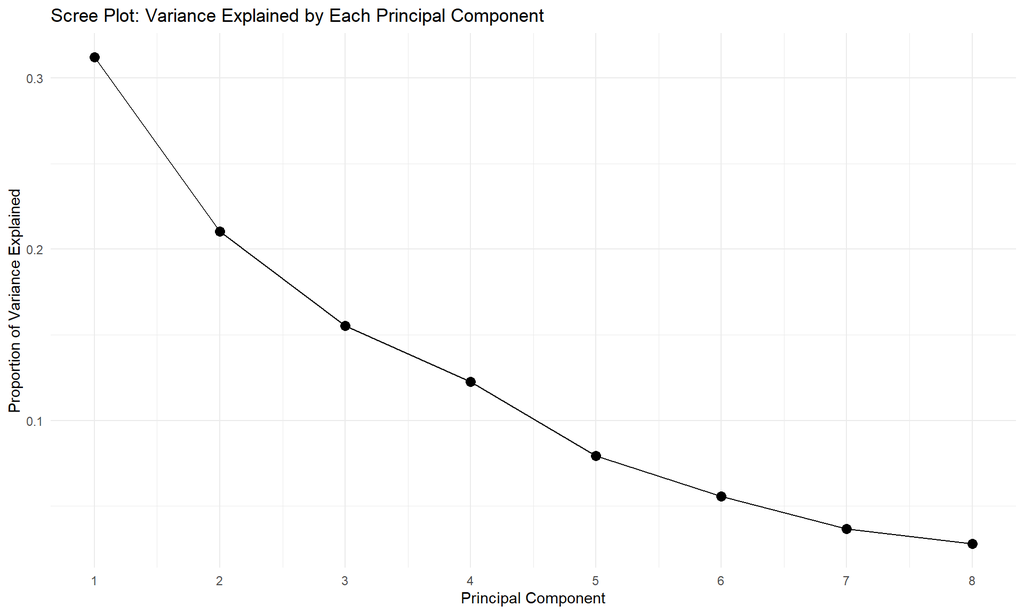

```r
# Calculate proportion of variance explained by each PC
# pca_cities$sdev gives you standard deviations
variance_explained <- pca_cities$sdev^2 / sum(pca_cities$sdev^2)

# Create a data frame with PC number and variance explained
scree_data <- data.frame(
  PC = 1:length(variance_explained),
  Variance_Explained = variance_explained
)

# Create a scree plot with PC on x-axis and variance on y-axis
# Use geom_line() and geom_point()
ggplot(scree_data, aes(x = PC, y = Variance_Explained)) +
  geom_line() +
  geom_point(size = 3) +
  labs(title = "Scree Plot: Variance Explained by Each Principal Component",
       x = "Principal Component",
       y = "Proportion of Variance Explained") +
  scale_x_continuous(breaks = 1:8) +
  theme_minimal()
```

**Question 3.2:** If you use just the first 2 PCs, what % of the total information do you keep?

```r
# Look at your data frame or summary output from above
cumulative_variance <- cumsum(variance_explained)
cumulative_variance[2]
```

```
## [1] 0.5224144
```

```r
# Store for inline reference
cum_var_2pc <- round(cumulative_variance[2] * 100, 1)
var_lost <- round((1 - cumulative_variance[2]) * 100, 1)
```

**Your answer:** Using just the first 2 PCs preserves approximately 52.2% of the total variance in the data. This means we retain more than half of the information while reducing from 8 dimensions to just 2.

**Question 3.3:** Make a business recommendation: Is going from 8 dimensions to 2 worth it? What do you gain? What do you lose?

**Your recommendation:** Yes, going from 8 to 2 dimensions is worthwhile for an initial screening tool. We gain simplicity and visualization capability - users can see all cities on a 2D map and quickly understand broad patterns. We lose about 47.8% of the information, which means some nuanced differences between cities are obscured. Recommendation: Use the 2-PC map for initial exploration and filtering, but provide detailed breakdowns of the original 8 metrics for final decision-making.

## Part 4: The World City Map! (12 minutes)

Now let’s see where different cities fall on the PC map!

**Question 4.1:** Create a biplot showing cities positioned by PC1 and PC2.

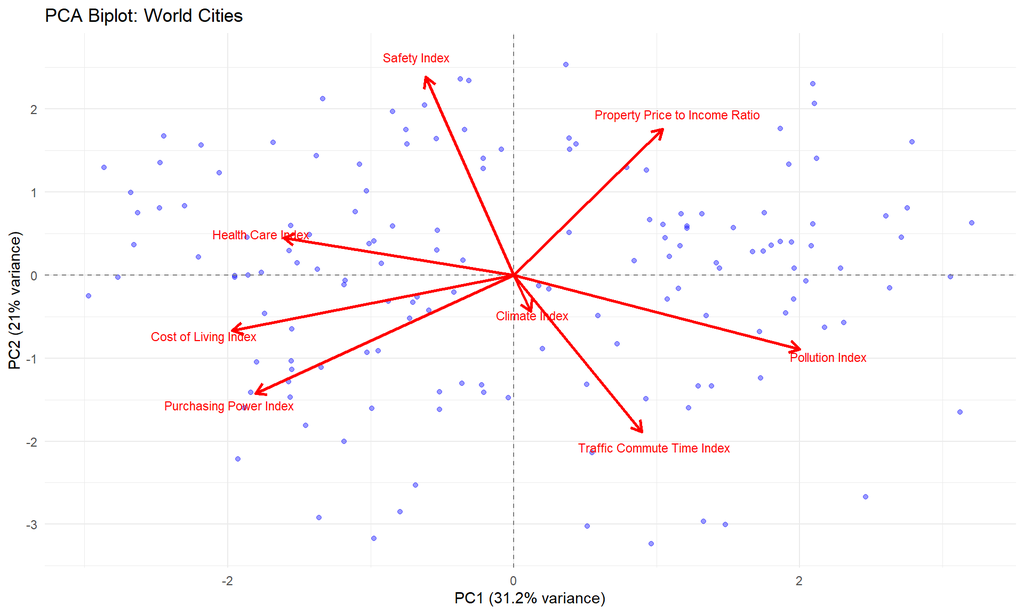

```r
# Extract PC scores (the transformed data)
pc_scores <- as.data.frame(pca_cities$x[, 1:2])
pc_scores$City <- cities$City

# Get the loadings (how variables contribute to PCs)
loadings <- as.data.frame(pca_cities$rotation[, 1:2])
loadings$Variable <- rownames(loadings)

# Create a biplot using ggplot
# You need:
# - geom_point() for the cities (using PC scores)
# - geom_segment() for arrows (using loadings, scaled up for visibility)
# - geom_text() to label the variable arrows
# - reference lines at x=0 and y=0

# Scale factor for arrows
arrow_scale <- 4

ggplot() +
  # Plot cities
  geom_point(data = pc_scores, aes(x = PC1, y = PC2), alpha = 0.4, color = "blue") +
  # Add reference lines
  geom_hline(yintercept = 0, linetype = "dashed", color = "gray50") +
  geom_vline(xintercept = 0, linetype = "dashed", color = "gray50") +
  # Add variable arrows
  geom_segment(data = loadings,
               aes(x = 0, y = 0, xend = PC1 * arrow_scale, yend = PC2 * arrow_scale),
               arrow = arrow(length = unit(0.3, "cm")),
               color = "red", size = 1) +
  # Add variable labels
  geom_text(data = loadings,
            aes(x = PC1 * arrow_scale * 1.1, y = PC2 * arrow_scale * 1.1, label = Variable),
            color = "red", size = 3) +
  labs(title = "PCA Biplot: World Cities",
       x = paste0("PC1 (", round(variance_explained[1] * 100, 1), "% variance)"),
       y = paste0("PC2 (", round(variance_explained[2] * 100, 1), "% variance)")) +
  theme_minimal()
```

**Question 4.2:** Based on the arrows, describe a city that would be in the:

- **Top-right quadrant** (high PC1, high PC2): High property prices
- **Bottom-right quadrant** (high PC1, low PC2): High pollution and high traffic commute times
- **Top-left quadrant** (low PC1, high PC2): Safe and good health care
- **Bottom-left quadrant** (low PC1, low PC2): High cost of living and high purchasing power. Probably major capital cities

**Question 4.3:** Let’s find specific cities! Label some major cities and see where they fall.

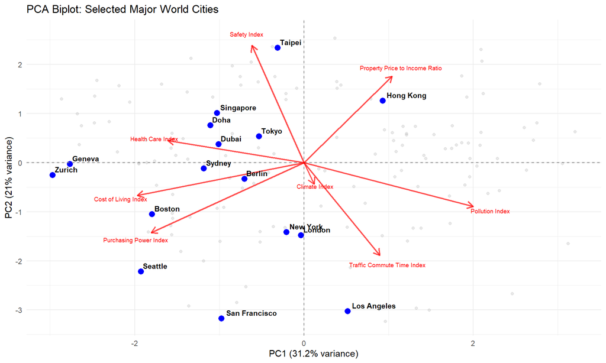

```r
# Choose some cities you're interested in and filter to them
cities_of_interest <- c("Geneva","Boston","New York", "London", "Tokyo", "Singapore",
                       "Berlin", "Mumbai", "Zurich", "Dubai",
                       "Mexico City", "Sydney", "Los Angeles", "San Francisco","Taipei","Hong Kong","Seattle","Doha")

pc_scores_labeled <- pc_scores %>%
  filter(City %in% cities_of_interest)

# Recreate your biplot from 4.1 but add city labels
# Use geom_text() to add labels for your selected cities
ggplot() +
  # Plot all cities
  geom_point(data = pc_scores, aes(x = PC1, y = PC2), alpha = 0.3, color = "gray70") +
  # Highlight selected cities
  geom_point(data = pc_scores_labeled, aes(x = PC1, y = PC2), color = "blue", size = 3) +
  # Add reference lines
  geom_hline(yintercept = 0, linetype = "dashed", color = "gray50") +
  geom_vline(xintercept = 0, linetype = "dashed", color = "gray50") +
  # Add variable arrows
  geom_segment(data = loadings,
               aes(x = 0, y = 0, xend = PC1 * arrow_scale, yend = PC2 * arrow_scale),
               arrow = arrow(length = unit(0.3, "cm")),
               color = "red", size = 0.8, alpha = 0.7) +
  # Add variable labels
  geom_text(data = loadings,
            aes(x = PC1 * arrow_scale * 1.1, y = PC2 * arrow_scale * 1.1, label = Variable),
            color = "red", size = 2.5) +
  # Add city labels
  geom_text(data = pc_scores_labeled,
            aes(x = PC1, y = PC2, label = City),
            size = 3, hjust = -0.1, vjust = -0.5, fontface = "bold") +
  labs(title = "PCA Biplot: Selected Major World Cities",
       x = paste0("PC1 (", round(variance_explained[1] * 100, 1), "% variance)"),
       y = paste0("PC2 (", round(variance_explained[2] * 100, 1), "% variance)")) +
  theme_minimal()
```

**Your observations:** Pick 3-4 cities from the plot and explain why they landed where they did.

**Your answer:**

- Taipei has high safety, property prices, and decent commute times. It has moderate cost of living and purchasing power.
- Geneva and Zurich have high cost of living, health care, purchasing power. They have low pollution and decent safety.
- SF scores low on safety and commuting. However, it has high purchasing power

**Question 4.4:** Find your hometown or a city you’ve lived in! Where does it fall on the map? Does this match your experience?

```r
# Search for your city and find its PC1 and PC2 scores
# Example: searching for Los Angeles
my_city <- "Los Angeles"
pc_scores %>% filter(City == my_city)
```

```
##         PC1       PC2        City
## 1 0.5150822 -3.023787 Los Angeles
```

## Part 5: Discovering City “Types” (10 minutes)

Your client wants to categorize cities into lifestyle groups. Let’s use clustering!

**Question 5.1:** Perform k-means clustering with k=4 on the first two PC scores.

```r
# Set seed for reproducibility
set.seed(122)

# Perform k-means clustering on the first 2 PC scores
kmeans_result <- kmeans(pca_cities$x[, 1:2], centers = 4, nstart = 25)

# Add cluster assignments to your data
cities_clustered <- cities %>%
  mutate(PC1 = pca_cities$x[, 1],
         PC2 = pca_cities$x[, 2],
         Cluster = as.factor(kmeans_result$cluster))
```

**Question 5.2:** Visualize the clusters on the PC map!

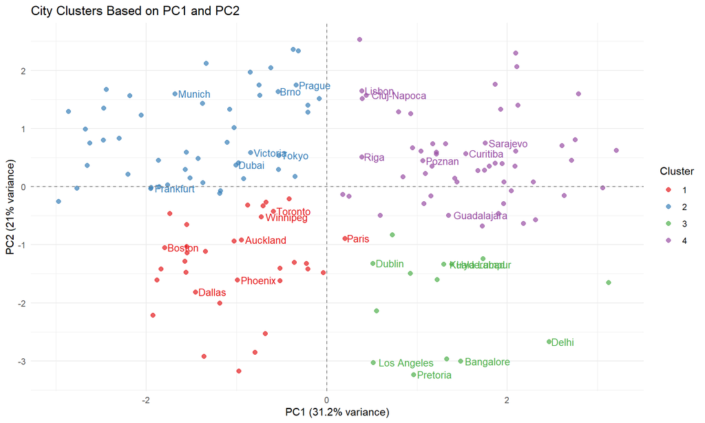

```r
# Create a scatter plot with PC1 and PC2, colored by cluster
# Add reference lines at 0
# Label some representative cities from each cluster (randomly sampled)
set.seed(122)  # For reproducibility
cities_to_label <- cities_clustered %>%
  group_by(Cluster) %>%
  slice_sample(n = 7) %>%
  ungroup()

ggplot(cities_clustered, aes(x = PC1, y = PC2, color = Cluster)) +
  geom_point(size = 2, alpha = 0.7) +
  geom_text(data = cities_to_label, aes(label = City),
            size = 3.5, hjust = -0.1, vjust = 0.5, show.legend = FALSE) +
  geom_hline(yintercept = 0, linetype = "dashed", color = "gray50") +
  geom_vline(xintercept = 0, linetype = "dashed", color = "gray50") +
  labs(title = "City Clusters Based on PC1 and PC2",
       x = paste0("PC1 (", round(variance_explained[1] * 100, 1), "% variance)"),
       y = paste0("PC2 (", round(variance_explained[2] * 100, 1), "% variance)")) +
  theme_minimal() +
  scale_color_brewer(palette = "Set1")
```

**Question 5.3:** Let’s name each cluster! Look at the average characteristics.

```r
# Look at cluster centers
kmeans_result$centers
```

```
##         PC1        PC2
## 1 -1.012270 -1.3224692
## 2 -1.422871  0.8801290
## 3  1.300808 -1.9869519
## 4  1.572486  0.5246758
```

```r
# Calculate average of each index variable by cluster
cluster_summary <- cities_clustered %>%
  group_by(Cluster) %>%
  summarise(
    Count = n(),
    Avg_Purchasing_Power = mean(`Purchasing Power Index`),
    Avg_Safety = mean(`Safety Index`),
    Avg_Healthcare = mean(`Health Care Index`),
    Avg_Cost_of_Living = mean(`Cost of Living Index`),
    Avg_Property_Ratio = mean(`Property Price to Income Ratio`),
    Avg_Traffic = mean(`Traffic Commute Time Index`),
    Avg_Pollution = mean(`Pollution Index`),
    Avg_Climate = mean(`Climate Index`)
  )
print(cluster_summary)
```

```
## # A tibble: 4 × 10
##   Cluster Count Avg_Purchasing_Power Avg_Safety Avg_Healthcare
##   <fct>   <int>                <dbl>      <dbl>          <dbl>
## 1 1          33                131.        50.2           68.9
## 2 2          49                112.        70.9           74.0
## 3 3          14                113.        40.2           63.6
## 4 4          54                 65.8       60.8           62.2
## # ℹ 5 more variables: Avg_Cost_of_Living <dbl>, Avg_Property_Ratio <dbl>,
## #   Avg_Traffic <dbl>, Avg_Pollution <dbl>, Avg_Climate <dbl>
```

```r
# Look at example cities from each cluster
cities_clustered %>%
  group_by(Cluster) %>%
  slice_head(n = 5) %>%
  select(City, Cluster, PC1, PC2) %>%
  arrange(Cluster)
```

```
## # A tibble: 20 × 4
## # Groups:   Cluster [4]
##    City        Cluster    PC1    PC2
##    <chr>       <fct>    <dbl>  <dbl>
##  1 Perth       1       -1.57  -1.28
##  2 Austin      1       -1.56  -1.47
##  3 Brisbane    1       -1.55  -0.650
##  4 Melbourne   1       -1.55  -1.14
##  5 Seattle     1       -1.93  -2.21
##  6 The Hague   2       -2.86   1.30
##  7 Luxembourg  2       -2.65   0.365
##  8 Eindhoven   2       -2.68   0.992
##  9 Rotterdam   2       -2.63   0.750
## 10 Zurich      2       -2.97  -0.251
## 11 Pune        3        0.927 -1.49
## 12 Cape Town   3        0.550 -2.14
## 13 Bangalore   3        1.48  -3.00
## 14 Hyderabad   3        1.38  -1.33
## 15 Pretoria    3        0.963 -3.23
## 16 Jeddah      4        0.178 -0.132
## 17 Cluj-Napoca 4        0.438  1.58
## 18 Timisoara   4        0.392  1.52
## 19 Lisbon      4        0.388  1.65
## 20 Bratislava  4        0.793  1.29
```

(Note: The actual characteristics should be verified by examining the cluster_summary output above to see which cluster corresponds to which pattern.)

**Question 5.4:** Personal decision time! If you were choosing where to work after graduation, which cluster appeals most to you? Pick 2-3 cities from that cluster and explain why.

```r
# Filter to your preferred cluster and explore cities
# Example: looking at Cluster 1
cities_clustered %>%
  filter(Cluster == 1) %>%
  arrange(desc(PC1)) %>%
  select(City, `Cost of Living Index`, `Safety Index`, `Health Care Index`, `Climate Index`) %>%
  head(10)
```

```
## # A tibble: 10 × 5
##    City       `Cost of Living Index` `Safety Index` `Health Care Index`
##    <chr>                       <dbl>          <dbl>               <dbl>
##  1 Paris                        73.6           42.3                77.3
##  2 London                       78.7           45.4                70
##  3 New York                    100             49.2                62.7
##  4 Brussels                     66.6           44.4                73.6
##  5 Manchester                   65.7           44.7                74.4
##  6 Riyadh                       49.8           74.5                64.7
##  7 Miami                        77             47.3                63.6
##  8 Las Vegas                    68.5           44.5                54.1
##  9 Toronto                      66.3           56.7                74.3
## 10 Cork                         68.6           64.2                55.8
## # ℹ 1 more variable: `Climate Index` <dbl>
```

## Bonus Challenges (if you finish early!)

**Challenge 1: The Perfect City?** Which city is closest to having high values on ALL positive metrics (high purchasing power, safety, healthcare, climate AND low cost, pollution)?

```r
# Create a composite score with desired direction
cities %>%
  mutate(
    perfect_score = `Purchasing Power Index` + `Safety Index` +
                   `Health Care Index` + `Climate Index` -
                   `Cost of Living Index` - `Pollution Index` -
                   `Traffic Commute Time Index` - `Property Price to Income Ratio`
  ) %>%
  arrange(desc(perfect_score)) %>%
  select(City, perfect_score, `Purchasing Power Index`, `Safety Index`,
         `Health Care Index`, `Climate Index`, `Cost of Living Index`, `Pollution Index`) %>%
  head(10)
```

```
## # A tibble: 10 × 8
##    City  perfect_score Purchasing Power Ind…¹ `Safety Index` `Health Care Index`
##    <chr>         <dbl>                  <dbl>          <dbl>               <dbl>
##  1 Luxe…          286                   176.            71.4                76.6
##  2 The …          285.                  139.            79.8                80.7
##  3 Eind…          270.                  139.            78.1                78.9
##  4 Rott…          266.                  139.            71.6                81.2
##  5 Zuri…          234.                  181.            77.2                70.3
##  6 Stut…          229.                  146.            65.5                76.7
##  7 Fran…          229.                  142.            53.9                76.7
##  8 Vien…          228.                  113.            69.9                79.6
##  9 Cope…          226                   124.            74.3                77.2
## 10 Vale…          226.                   83.9           69.8                80.3
## # ℹ abbreviated name: ¹`Purchasing Power Index`
## # ℹ 3 more variables: `Climate Index` <dbl>, `Cost of Living Index` <dbl>,
## #   `Pollution Index` <dbl>
```

**Challenge 2: US Cities Showdown** Filter to only US cities and create a new biplot. How do different US cities compare to each other?

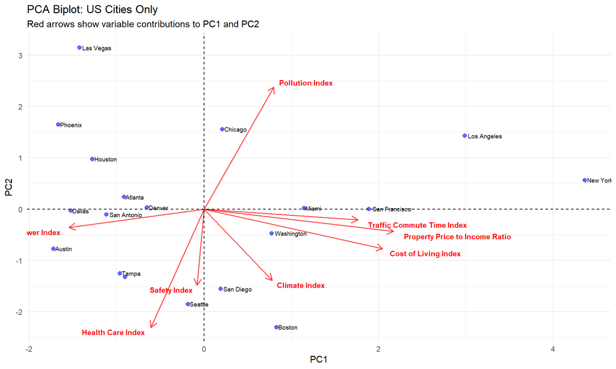

```r
# Filter to US cities and re-run PCA
us_cities <- cities %>%
  filter(grepl("UnitedStates", Country))

us_metrics <- us_cities %>%
  select(`Purchasing Power Index`, `Safety Index`, `Health Care Index`,
         `Cost of Living Index`, `Property Price to Income Ratio`,
         `Traffic Commute Time Index`, `Pollution Index`, `Climate Index`)

pca_us <- prcomp(us_metrics, scale = TRUE, center = TRUE)

us_pc_scores <- as.data.frame(pca_us$x[, 1:2])
us_pc_scores$City <- us_cities$City

# Extract loadings for biplot arrows
loadings <- as.data.frame(pca_us$rotation[, 1:2])
loadings$Variable <- rownames(loadings)

# Scale the arrows for better visualization (multiply by a constant)
arrow_scale <- 4
loadings$PC1 <- loadings$PC1 * arrow_scale
loadings$PC2 <- loadings$PC2 * arrow_scale

ggplot(us_pc_scores, aes(x = PC1, y = PC2)) +
  geom_point(alpha = 0.6, color = "blue", size = 2) +
  geom_text(aes(label = City), size = 2.5, hjust = -0.1, vjust = 0.5, check_overlap = TRUE) +
  # Add biplot arrows
  geom_segment(data = loadings,
               aes(x = 0, y = 0, xend = PC1, yend = PC2),
               arrow = arrow(length = unit(0.3, "cm")),
               color = "red", linewidth = 0.7, alpha = 0.7) +
  geom_text(data = loadings,
            aes(x = PC1, y = PC2, label = Variable),
            color = "red", size = 3, fontface = "bold",
            hjust = ifelse(loadings$PC1 > 0, -0.1, 1.1),
            vjust = ifelse(loadings$PC2 > 0, -0.3, 1.3)) +
  geom_hline(yintercept = 0, linetype = "dashed") +
  geom_vline(xintercept = 0, linetype = "dashed") +
  labs(title = "PCA Biplot: US Cities Only",
       subtitle = "Red arrows show variable contributions to PC1 and PC2",
       x = "PC1", y = "PC2") +
  theme_minimal()
```

```r
cities_with_pc <- cities %>%
  mutate(PC1 = pca_cities$x[, 1])

cities_with_pc %>%
  filter(`Cost of Living Index` < 70) %>%
  arrange(desc(PC1)) %>%
  select(City, PC1, `Cost of Living Index`, `Safety Index`, `Health Care Index`,
         `Purchasing Power Index`) %>%
  head(10)
```

```
## # A tibble: 10 × 6
##    City            PC1 `Cost of Living Index` `Safety Index` `Health Care Index`
##    <chr>         <dbl>                  <dbl>          <dbl>               <dbl>
##  1 Baku           3.20                   32.8           69.5                47.7
##  2 Kolkata        3.12                   21.1           54                  59.8
##  3 Odessa (Odes…  3.05                   27.2           45.9                51
##  4 Shanghai       2.79                   36.5           71.3                64.4
##  5 Tbilisi        2.75                   35.7           74.4                55.1
##  6 Skopje         2.71                   34.6           53.2                54.7
##  7 Belo Horizon…  2.63                   30.3           39.4                64.7
##  8 Belgrade       2.61                   42.1           61.9                53.2
##  9 Delhi          2.46                   23.9           41.1                66.5
## 10 Istanbul       2.31                   39.1           52.2                70
## # ℹ 1 more variable: `Purchasing Power Index` <dbl>
```

**Challenge 4: Climate vs Everything Else** Does climate actually matter much for overall city quality? Create a scatter plot of Climate Index vs PC1 scores.

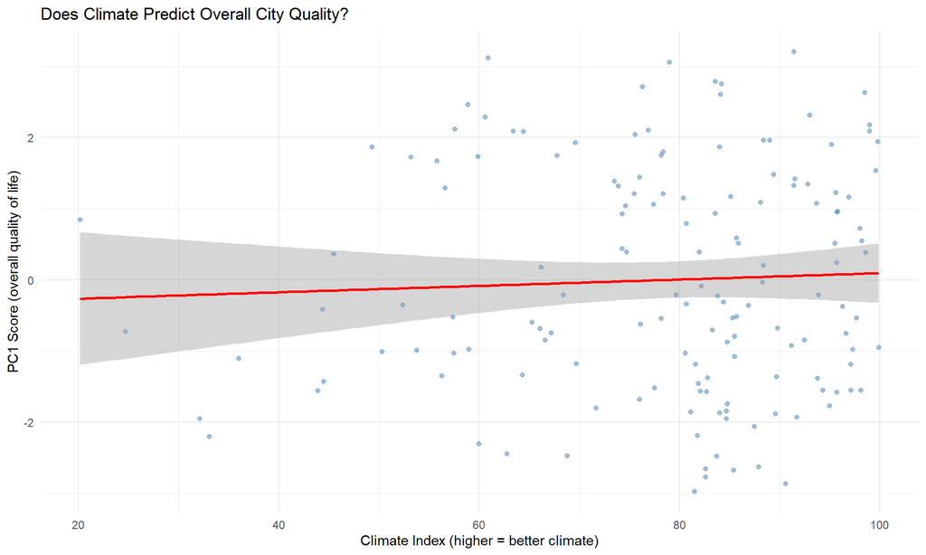

```r
cities_with_pc <- cities %>%
  mutate(PC1 = pca_cities$x[, 1])

ggplot(cities_with_pc, aes(x = `Climate Index`, y = PC1)) +
  geom_point(alpha = 0.5, color = "steelblue") +
  geom_smooth(method = "lm", se = TRUE, color = "red") +
  labs(title = "Does Climate Predict Overall City Quality?",
       x = "Climate Index (higher = better climate)",
       y = "PC1 Score (overall quality of life)") +
  theme_minimal()
```

**Challenge 5: Your Custom Metric** Create your own “ideal city score” based on what YOU value most. Weight the variables however you want. Which city scores the best?

```r
# Example: my_score = 2*Safety + 1*Healthcare - 1*Cost + ...
cities %>%
  mutate(
    my_score = 2 * `Safety Index` +
               1.5 * `Health Care Index` +
               1 * `Purchasing Power Index` +
               1 * `Climate Index` -
               1.5 * `Cost of Living Index` -
               0.5 * `Pollution Index` -
               0.5 * `Traffic Commute Time Index` -
               1 * `Property Price to Income Ratio`
  ) %>%
  arrange(desc(my_score)) %>%
  select(City, my_score, `Safety Index`, `Health Care Index`, `Cost of Living Index`) %>%
  head(15)
```

```
## # A tibble: 15 × 5
##    City       my_score `Safety Index` `Health Care Index` `Cost of Living Index`
##    <chr>         <dbl>          <dbl>               <dbl>                  <dbl>
##  1 The Hague      395.           79.8                80.7                   60.2
##  2 Luxembourg     389.           71.4                76.6                   62
##  3 Eindhoven      378.           78.1                78.9                   62.2
##  4 Rotterdam      371.           71.6                81.2                   61.3
##  5 Abu Dhabi      361.           88.2                71.1                   54.1
##  6 Pune           346.           59                  65.7                   24.1
##  7 Taipei         344.           83.7                86.6                   47
##  8 Bangalore      336.           45.6                65.1                   25.8
##  9 Valencia       336.           69.8                80.3                   47.2
## 10 Stuttgart      335.           65.5                76.7                   64.2
## 11 Tokyo          331.           76                  79                     51.9
## 12 Brno           328.           74.5                76.3                   42.8
## 13 Zurich         328.           77.2                70.3                  100.
## 14 Muscat         326.           80.6                64.2                   42.8
## 15 Brisbane       326.           63.3                74.5                   67.9
```

## Reflection Questions

**1. Personal Insight:** Based on this analysis, are there any cities you’d now consider living in that you hadn’t thought about before?

Yes, exploring 150 cities revealed options like Adelaide, Canberra, or some mid-sized European cities that I hadn’t considered before. They appear to offer excellent quality of life without the extreme costs of major capitals. I was also surprised to see how some Eastern European cities perform well on quality metrics while remaining affordable.

**2. Missing Variables:** What important factors about cities are NOT in this dataset?

Cultural factors like language, food scene, nightlife, proximity to family, job opportunities in specific industries, visa/immigration policies, political stability, and personal networks are all missing but crucial for real decisions. Also missing are things like access to nature, diversity and inclusion metrics, and education quality which would be important for long-term settlement.

**3. Limitations:** What are the limitations of reducing 8 dimensions to 2? When might you need to look at the original variables instead?

We lose 47.8% of the information. If someone has very specific priorities (e.g., they need excellent healthcare but don’t care about climate), the PC scores might not reflect that. You’d need the original variables for final decision-making or when specific trade-offs matter. For example, two cities might have similar PC scores but very different safety vs. cost profiles.

**4. Decision Making:** If you were actually choosing a city to move to, how would you use this PCA analysis in combination with other factors?

I’d use PCA to narrow down from 150 cities to maybe 20-30 candidates that generally match my preferences on the major dimensions. Then I’d look at the detailed metrics for those cities, research job opportunities in my field, consider visa requirements, and possibly visit before making a final decision. The PCA is great for the initial filter but shouldn’t be the only factor.

**5. Explain to a Friend:** Can you explain in 2-3 sentences what PCA did and why it’s useful for this city comparison problem?

PCA took 8 different city quality metrics and combined them into 2 main dimensions that capture the most important patterns of variation across cities. Instead of looking at 8 separate numbers for each city, we can visualize all cities on a 2D map where similar cities are close together. This makes it much easier to compare hundreds of cities at once and identify groups of similar cities.